# Test Results - Kohonen WTA Network

Magda

2026-05-07

# Kohonen Neural Network Test Results

## Wstęp

● Celem niniejszej pracy jest opracowanie oraz ocena modelu sieci neuronowej przeznaczonego do klasyfikacji spółek o podobnej dynamice wzrostu wchodzących w skład indeksu NASDAQ. ● Zadaniem modelu będzie przypisanie spółki do odpowiedniej kategorii na podstawie jej historycznych notowań giełdowych. ● Proces klasyfikacji zostanie oparty na wybranych cechach opisujących zachowanie kursu, takich jak nachylenie trendu czy odchylenie standardowe reszt modelu regresyjnego. ● Dane wejściowe zostały pobrane z serwisu Yahoo Finance. Do analizy zostały użyte ceny zamknięcia spółek giełdowych (dzienne), notowanych na NASDAQ od przynajmniej 5-ciu lat. Analizowano notowania spółek z ostatnich 3000 dni, przy czym były to spółki obecne na giełdzie przynajmniej przez 5 lat. ● W zbiorze uczącym znalazło się 1821 podmiotów, a w testowym 456 ● Należy rozróżnić spółki na podstawie tempa wzrostu notowań (zostanie wybrany i wyestymowany model najlepiej opisujący zmienność danych (liniowy, wykładniczy lub wielomianowy)

## Problem mierzenia dokładności

Jeśli klasy zostaną wprowadzone ręcznie, model może faworyzować niektóre parametry, I pomijać cechy danych, które są trudne do zauważenia, ale które mają znaczący wpływ na wyniki. W tym przypadku nie można ,,ręcznie’’ przypisać do danych pożądanych wyników klasyfikacji. Byłyby one nieobiektywne. ● W konsekwencji, proces budowy modelu powinien wykorzystywać uczenie nienadzorowane: model sam podzieli spółki na sensowne grupy bez wcześniejszych założeń.

Ponieważ dane nie mogą być ręcznie podzielone na klasy przed treningiem, sprawdzenie dokładności modelu nie może polegać na policzeniu odsetka poprawnych przyporządkowań do klas. Zamiast tego jako miary dokładności użyto wartości cosinusa kąta między zwycięskim neuronem a wektorem wejściowym (im lepsze dopasowanie, tym cosinus kąta jest bliżej 1 (wówczas kąt jest bliski 0)).

## Parametry wejściowe wektora

#### Pierwsza warstwa:

- trend = współczynnik kierunkowy × 100 (dla Linear/Exponential) lub pochodna w środku (dla Polynomial)
  - mape = średni błąd procentowy: mean(|y_test - pred| / |y_test|) × 100
  - q_slope = nachylenie między 1. a 3. kwartylem: (y_test[q3] - y_test[q1]) / (X_test[q3] - X_test[q1])
  - curvature = 0 (Linear), b² (Exponential), c (współczynnik x² dla Polynomial)
  - highest_p1..p5 = najwyższy punkt w każdym z 5 okresów (przesunięcie od środka okresu)
  - rmse_p1..p5 = błąd RMSE w każdym z 5 okresów

#### Druga warstwa:

Bliskość danych z wektora wejsciowego do zwycięskiego neuronu z pierwszej warstwy, przekształcona przez funkcję aktywacji

## Proces uczenia i architektura sieci

Użyto sieci Kohenena, wektory są normalizowane. Podczas treningu aktualizowane są wagi jedynie zwycięskiego neuronu wg wzoru: w_new = w_old + η · (x - w_old)

## Poniżej zostały zaprezentowane wyniki dopasowania sieci w zależności od liczby neuronów w obu warstwach, szybkości zmiany współczynnika eta (learning rate), jego początkowej wartości, liczby epok, użytej funkcji aktywacji między 1 i 2 warstwą oraz sposobu podziału danych za zbiór uczący i testowy

**Generation Date:** 2026-05-07 10:07:27

## Series 1: Number of L1 Neurons (L2=5)

### Cosine Similarity Comparison

Comparison: 1-Layer vs 2-Layer Networks

| NetworkType | Param | TrainCosine | TrainCosineStd | TestCosine | TestCosineStd |
| --- | --- | --- | --- | --- | --- |
| 1-layer | 10 | 0.9703 | 0.0038 | 0.9674 | 0.0033 |
| 1-layer | 20 | 0.9779 | 0.0016 | 0.9748 | 0.0016 |
| 1-layer | 40 | 0.9822 | 0.0012 | 0.9794 | 0.0014 |
| 1-layer | 60 | 0.9828 | 0.0010 | 0.9801 | 0.0013 |
| 1-layer | 80 | 0.9843 | 0.0008 | 0.9813 | 0.0008 |
| 2-layer | 10 | 0.9530 | 0.0061 | 0.9490 | 0.0044 |
| 2-layer | 20 | 0.9659 | 0.0055 | 0.9608 | 0.0067 |
| 2-layer | 40 | 0.9725 | 0.0049 | 0.9688 | 0.0046 |
| 2-layer | 60 | 0.9734 | 0.0034 | 0.9687 | 0.0036 |
| 2-layer | 80 | 0.9764 | 0.0021 | 0.9712 | 0.0029 |

### Train vs Test: Num of L1 neurons

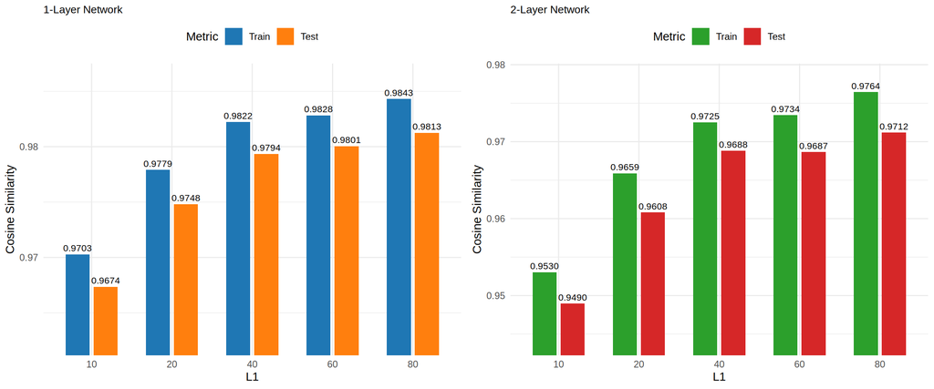

## Series 2: Number of L2 Neurons (L1=40)

### Cosine Similarity Comparison

Comparison: 1-Layer vs 2-Layer Networks

| NetworkType | Param | TrainCosine | TrainCosineStd | TestCosine | TestCosineStd |
| --- | --- | --- | --- | --- | --- |
| 1-layer | 0 | 0.9822 | 0.0012 | 0.9794 | 0.0014 |
| 1-layer | 0 | 0.9822 | 0.0012 | 0.9794 | 0.0014 |
| 1-layer | 0 | 0.9822 | 0.0012 | 0.9794 | 0.0014 |
| 1-layer | 0 | 0.9822 | 0.0012 | 0.9794 | 0.0014 |
| 1-layer | 0 | 0.9822 | 0.0012 | 0.9794 | 0.0014 |
| 2-layer | 3 | 0.9757 | 0.0026 | 0.9742 | 0.0026 |
| 2-layer | 5 | 0.9725 | 0.0049 | 0.9688 | 0.0046 |
| 2-layer | 10 | 0.9684 | 0.0019 | 0.9631 | 0.0049 |
| 2-layer | 20 | 0.9652 | 0.0004 | 0.9570 | 0.0031 |

### Train vs Test: num of L2 neurons

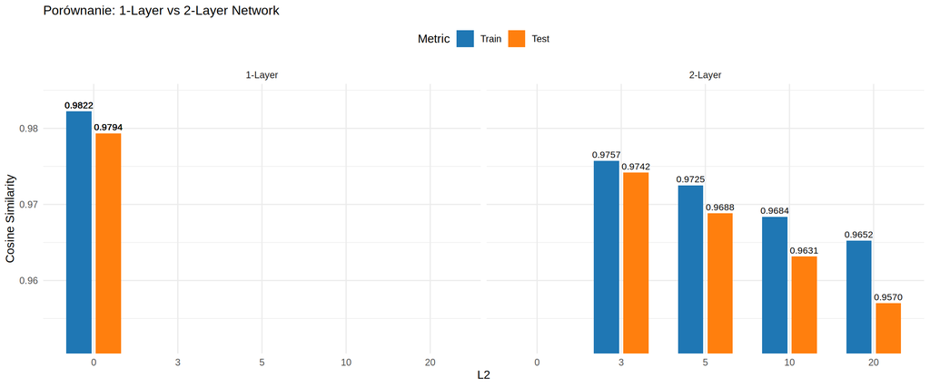

## Series 3: Learning Rate (L1=40, L2=5)

### Cosine Similarity Comparison

Comparison: 1-Layer vs 2-Layer Networks

| NetworkType | Param | TrainCosine | TrainCosineStd | TestCosine | TestCosineStd |
| --- | --- | --- | --- | --- | --- |
| 1-layer | 0.3 | 0.9750 | 0.0037 | 0.9720 | 0.0038 |
| 1-layer | 0.5 | 0.9788 | 0.0028 | 0.9759 | 0.0038 |
| 1-layer | 0.7 | 0.9806 | 0.0024 | 0.9777 | 0.0024 |
| 1-layer | 0.9 | 0.9822 | 0.0012 | 0.9794 | 0.0014 |
| 2-layer | 0.3 | 0.9558 | 0.0107 | 0.9494 | 0.0128 |
| 2-layer | 0.5 | 0.9646 | 0.0088 | 0.9609 | 0.0096 |
| 2-layer | 0.7 | 0.9688 | 0.0079 | 0.9643 | 0.0077 |
| 2-layer | 0.9 | 0.9725 | 0.0049 | 0.9688 | 0.0046 |

### Train vs Test: Learning Rate

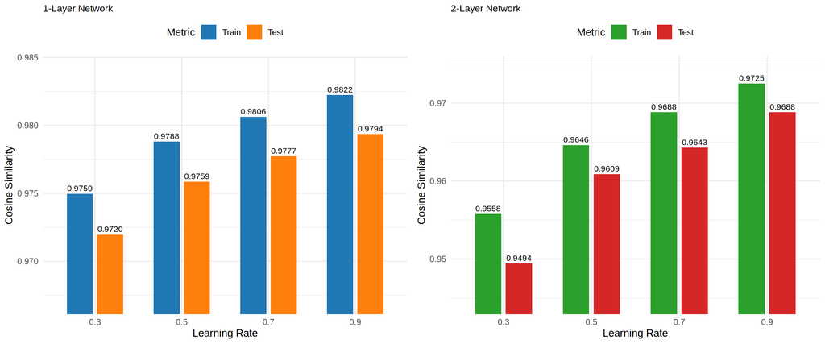

## Series 4: Learning Rate Decay (L1=40, L2=5)

### Cosine Similarity Comparison

Comparison: 1-Layer vs 2-Layer Networks

| NetworkType | Param | TrainCosine | TrainCosineStd | TestCosine | TestCosineStd |
| --- | --- | --- | --- | --- | --- |
| 1-layer | 0.90 | 0.9812 | 0.0021 | 0.9786 | 0.0026 |
| 1-layer | 0.95 | 0.9822 | 0.0012 | 0.9794 | 0.0014 |
| 1-layer | 0.98 | 0.9825 | 0.0015 | 0.9801 | 0.0008 |
| 1-layer | 0.99 | 0.9822 | 0.0019 | 0.9802 | 0.0010 |
| 2-layer | 0.90 | 0.9702 | 0.0055 | 0.9668 | 0.0055 |
| 2-layer | 0.95 | 0.9725 | 0.0049 | 0.9688 | 0.0046 |
| 2-layer | 0.98 | 0.9746 | 0.0044 | 0.9695 | 0.0048 |
| 2-layer | 0.99 | 0.9740 | 0.0041 | 0.9699 | 0.0055 |

### Train vs Test: Decay

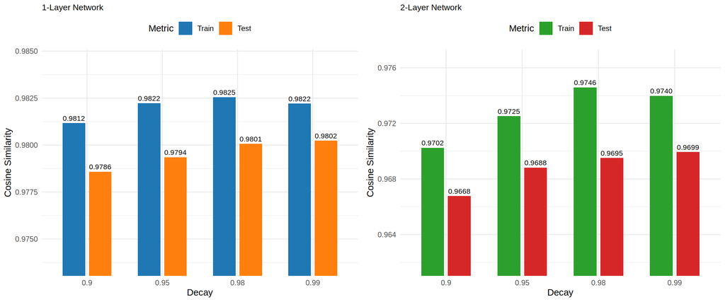

## Series 5: Number of Epochs (L1=40, L2=5)

### Cosine Similarity Comparison

Comparison: 1-Layer vs 2-Layer Networks

| NetworkType | Param | TrainCosine | TrainCosineStd | TestCosine | TestCosineStd |
| --- | --- | --- | --- | --- | --- |
| 1-layer | 50 | 0.9821 | 0.0015 | 0.9789 | 0.0017 |
| 1-layer | 100 | 0.9822 | 0.0012 | 0.9794 | 0.0014 |
| 1-layer | 200 | 0.9823 | 0.0012 | 0.9795 | 0.0012 |
| 1-layer | 500 | 0.9825 | 0.0011 | 0.9796 | 0.0011 |
| 2-layer | 50 | 0.9727 | 0.0042 | 0.9691 | 0.0049 |
| 2-layer | 100 | 0.9725 | 0.0049 | 0.9688 | 0.0046 |
| 2-layer | 200 | 0.9719 | 0.0046 | 0.9669 | 0.0057 |
| 2-layer | 500 | 0.9724 | 0.0045 | 0.9681 | 0.0054 |

### Train vs Test: num of Epochs

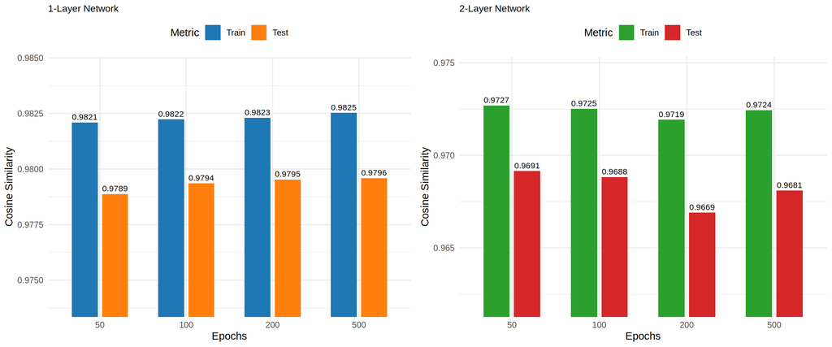

## Series 6: Different Activation Functions (L1=40, L2=5)

### Cosine Similarity Comparison

Comparison: 1-Layer vs 2-Layer Networks

| NetworkType | Param | TrainCosine | TrainCosineStd | TestCosine | TestCosineStd |
| --- | --- | --- | --- | --- | --- |
| 2-layer | gaussian | 0.9725 | 0.0049 | 0.9688 | 0.0046 |
| 2-layer | sigmoid | 0.9408 | 0.0083 | 0.9313 | 0.0107 |
| 2-layer | inverse | 0.9610 | 0.0083 | 0.9548 | 0.0039 |
| 2-layer | inverse_sq | 0.9758 | 0.0035 | 0.9723 | 0.0038 |

### Train vs Test: Activation func

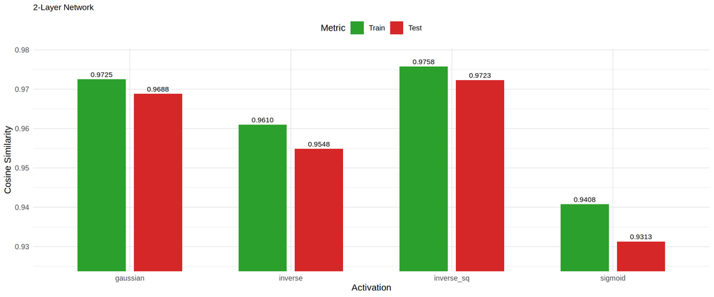

## Series 7: Train Ratio (L1=40, L2=5)

### Cosine Similarity Comparison

Comparison: 1-Layer vs 2-Layer Networks

| NetworkType | Param | TrainCosine | TrainCosineStd | TestCosine | TestCosineStd |
| --- | --- | --- | --- | --- | --- |
| 1-layer | 0.6 | 0.9814 | 0.0013 | 0.9789 | 0.0012 |
| 1-layer | 0.7 | 0.9817 | 0.0006 | 0.9798 | 0.0006 |
| 1-layer | 0.8 | 0.9822 | 0.0012 | 0.9794 | 0.0014 |
| 1-layer | 0.9 | 0.9831 | 0.0009 | 0.9788 | 0.0011 |
| 2-layer | 0.6 | 0.9706 | 0.0037 | 0.9663 | 0.0045 |
| 2-layer | 0.7 | 0.9709 | 0.0027 | 0.9680 | 0.0034 |
| 2-layer | 0.8 | 0.9725 | 0.0049 | 0.9688 | 0.0046 |
| 2-layer | 0.9 | 0.9738 | 0.0027 | 0.9665 | 0.0019 |

### Train vs Test Cosine Similarity (Side by Side)

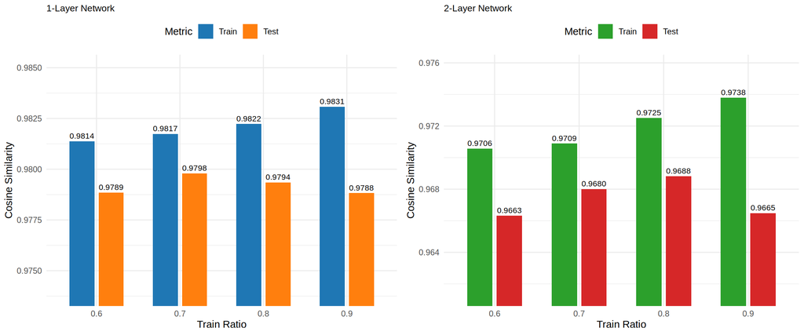

## Best Configuration

**Name:** S1_E: gaussian, lr=0.9 (1-layer)

- Number of layers: 1
- Number of neurons (L1): 80
- Activation function: gaussian
- Learning rate: 0.9
- Learning rate decay: 0.95
- Number of epochs: 100
- Train ratio: 0.8
- Train Cosine: 0.9843 +/- 0.0008
- Test Cosine: 0.9813 +/- 0.0008

## Przegląd literatury

● Sieci neuronowe’’ Tadeusiewicz omawia matematyczne podstawy uczenia sieci neuronowych, przedstawiając uczenie bez nadzoru oparte na regule Hebba i jej modyfikacji Grossberga („instar”). Analizuje też algorytmy rywalizacyjne Kohonena, podkreślając ich związki z regułą Hebba oraz różnice, takie jak aktualizacja wag tylko neuronu zwycięskiego i normalizacja wektorów wagowych. ● ,Multi-layer Hebbian networks with modern deep learning frameworks’’ (Thomas Miconi) Celem jest pokazanie, że reguły Hebba, Instar Grossberga i Oji można wdrożyć w nowoczesnych frameworkach deep learning bez specjalnych modyfikacji ● ,,Review of stability properties of neural plasticity rules for implementation on memristive neuromorphic hardware’’ ( Anatoli Gorchetchnikov) Artykuł analizuje stabilność reguł plastyczności synaptycznej w neuromorficznych systemach opartych na memrystorach. Omawia trzy klasy: Hebbian learning, reguły progowe (np. BCM theory) oraz czasowe (np. Temporal Difference learning), wskazując, że wiele z nich jest niestabilnych. Wyróżnia się reguła instar, która zapewnia stabilną konwergencję wag i skutecznie odwzorowuje wzorce wejściowe, co czyni ją szczególnie użyteczną w praktyce.

## Bibliografia

● Gorchetchnikov Anatoli i in., Review of stability properties of neural plasticity rules for implementation on memristive neuromorphic hardware, 2011; ● Miconi Thomas, Multi-layer Hebbian networks with modern deep learning frameworks, 2021; ● Pedregosa Fabian i in., Scikit‑learn: Machine Learning in Python, 2011; ● Tadeusiewicz Ryszard, Sieci neuronowe, 1993;